# Analiza političarki

Tiana i Tea

10 06 2022

## Uvod

### Uvod

##### Ovaj projekt bavi se analizom sadržaja aktivnosti na webu povezanih s dvjema političarkama: Sandrom Benčić i Marijom Selak Raspudić. Navedene političarke odabrane su radi izražene aktivnosti na webu, njihove popularnosti i pripadnosti različitim političkim pozicijama (lijevo – desno). Obrađeni podaci tiču se ukupne aktivnosti povezane s navedenim političarkama na webu u vremenskom razdoblju od 19. veljače 2022. do 30. svibnja 2022., pri čemu će naglasak biti stavljen na deskriptivnu statistiku samih objava te prikaz portala po aktivnosti, „dosegu“, lajkovima, interakcijama i komentarima. Uz navedeno, koristit će se analiza sentimenta, odnosno emocionalnog tona korištenih riječi, a kroz grafičke prikaze biti će vidljiva frekvencija sentimenta kroz vrijeme, prikaz najkorištenijih negativnih, neutralnih i pozitivnih riječi, kao i „wordCloud“ navedenog. Također, u analizi sentimenta biti će prikazani 10 najnegativnijih portala te pripadajućih riječi, kao i 10 najpozitivnijih portala i pripadajućih riječi, a na kraju poglavlja prikazana je tablica s najbitnijim riječima u portalima s najvećim „dosegom“. Naposljetku biti će izložen grafički prikaz učestalosti korištenja riječi „Benčić“, „Možemo“, „Selak“ i „Most“ na trima najaktivnijim portalima te njihov potencijalni međuodnos. Cilj ovog projekta je izložiti medijski prikaz dviju političarki te pripadajuću web aktivnost.

## Deskriptivna statistika

### Broj podataka i broj varijabli

```
## [1] 2202   49
```

##### Prikaz ukupnog broja dobivenih podataka nad kojima je započeta analiza – 2 202, kao i prikaz ukupnog broja uvrštenih varijabli - 49.

### Vremenski raspon sakupljenih podataka

```
## [1] "2022-02-19 16:55:36 CET"  "2022-05-30 16:37:07 CEST"
```

##### Obrađeni podaci tiču se vremenskog perioda od 19. veljače 2022. do 30. svibnja 2022.

### Izvor podataka i broj podataka u pojedinim izvorima

```
##    SOURCE_TYPE    N
## 1:         web 1823
## 2:     youtube  185
## 3:     twitter   84
## 4:    facebook   51
## 5:       forum   39
## 6:      reddit   13
## 7:     comment    5
## 8:   instagram    2
```

##### Prikaz svih aktivnosti vezanih uz navedenu temu te njihov broj u navedenim izvorima. Najveća aktivnost primjetna je na webu (1 823 objava), a najmanja na Instagramu (2 objave).

### Broj slova u naslovu

```
##    SOURCE_TYPE Avg   STD min max
## 1:   instagram 346   5.7 342 350
## 2:      reddit 218 120.9  25 349
## 3:     twitter 214 105.4  28 569
## 4:    facebook 130  34.9  13 160
## 5:         web  84  27.9   5 160
## 6:     youtube  69  19.2  27 100
## 7:       forum  46  25.9   2  93
## 8:     comment  27   7.8  22  39
```

### Broj slova u tekstu

```
##    SOURCE_TYPE  Avg  STD min   max
## 1:         web 4224 3047 105 32121
## 2:       forum 1206 1280  97  6121
## 3:     youtube 1182  871  38  3622
## 4:   instagram  542   76 488   596
## 5:     comment  500  504 103  1344
## 6:    facebook  460  564  13  2207
## 7:     twitter  214  105  28   569
## 8:      reddit   NA   NA  NA    NA
```

##### Prikaz deskriptivne statistike slova u tekstu u različitim izvorima. Vidljiv je najveći prosjek u dužini teksta na Webu, a najmanji – nepostojeći na Redditu (NA). Najveće odstupanje pojavljuje se na Webu (std 3047), a najmanja ponovno na Redditu.

### Portali prema aktivnosti

```
##                     FROM  N
##   1:        glasistre.hr 87
##   2:         direktno.hr 86
##   3:              hrt.hr 86
##   4:          n1info.com 71
##   5:          tportal.hr 70
##  ---
## 236:             klix.ba  1
## 237:              cdm.me  1
## 238:        ps-portal.eu  1
## 239: mariborskiodmev.com  1
## 240:        ntvarena.com  1
```

##### Prikaz top 5 portala prema aktivnosti na temu Sande Benčić i Marije Selak Raspudić, kao i broj njihovih objava, te zadnjih 5 portala i broj njihovih objava. Na prvom mjestu nalazi se *glasistre.hr* s 87 objava, a odmah iza direktno.hr i hrt.hr. Na zadnjem mjestu nalazi se više portala s jednom objavom – *ntvarena.com, mariborskiodmev.com…*

### Portali prema “dosegu”

```
##                  FROM   REACH
##   1:         index.hr 421,395
##   2:       n1info.com 294,969
##   3:      jutarnji.hr 212,064
##   4:      zagreb.info 198,157
##   5:        24sata.hr 169,532
##  ---
## 236:       nportal.rs       0
## 237:      dvaosam.com       0
## 238: nasabujstina.com       0
## 239:    buzimpress.ba       0
## 240:           hdz.hr       0
```

##### Prikaz prvih i zadnjih 5 portala prema dosegu ili reachu na navedenu temu, pri čemu je vodeći *indeks.hr*, a zadnje mjesto ponovno dijeli više portala – reach 0 (*hdz.hr, budimpress.ba…*).

### Portali prema lajkovima

```
##                     FROM   LIKE
##   1:            index.hr 10,474
##   2:          n1info.com  8,006
##   3:         telegram.hr  7,097
##   4:         direktno.hr  5,558
##   5:         vecernji.hr  4,707
##  ---
## 236:          novosti.rs      0
## 237:             novi.ba      0
## 238:              cdm.me      0
## 239: mariborskiodmev.com      0
## 240:        ntvarena.com      0
```

##### Prikaz prvih i zadnjih 5 portala po broju lajkova na navedenu temu. Vodeći portal prema broju lajkova je *indeks.hr* – 10 474, a prate ga *n1info.com* – 8 006, *telegram.hr*, *direktno.hr* i *vecernji.hr*. Bez lajkova na navedenu temu ima više portala, no zadnji u podacima se prikazao *ntvarena.com* – 0 lajkova.

### Portali prema interakcijama

```
##              FROM INTERACTIONS
##   1:     index.hr       15,739
##   2:   n1info.com       13,468
##   3:  telegram.hr       11,337
##   4:  direktno.hr       10,499
##   5: priznajem.hr       10,273
##  ---
## 236:    ipress.hr            0
## 237: tvprofil.com            0
## 238:    vecer.com            0
## 239:   blogger.ba            0
## 240:      novi.ba            0
```

### Portali prema komentarima

```
##                     FROM COMMENT
##   1:        priznajem.hr   5,527
##   2:           24sata.hr   5,071
##   3:          n1info.com   5,001
##   4:         vecernji.hr   4,733
##   5:            index.hr   4,655
##  ---
## 236:          novosti.rs       0
## 237:             novi.ba       0
## 238:              cdm.me       0
## 239: mariborskiodmev.com       0
## 240:        ntvarena.com       0
```

##### Prikaz portala na navedenu temu prema broju komentara. Najveći broj komentara – 5 527 zabilježen je na portalu priznajem.hr, a bez komentara su portali *ntvarena.com*, *mariboraskiodmev.com*, *cdm.me*.

### Broj podataka na webu

```
## [1] 1823   51
```

### Broj podataka nakon tokenizacije

```
## [1] 1201115      51
```

### Broj podataka nakon što maknemo “stop” riječi

##### “Stop” riječi su riječi koje smo izbacili iz analize, a to su najčešće prilozi, prijedlozi, veznici i slično.

```
## [1] 724055     51
```

[output not shown]

### Grafički prikaz frekvencija korištenih riječi u “oblaku riječi”

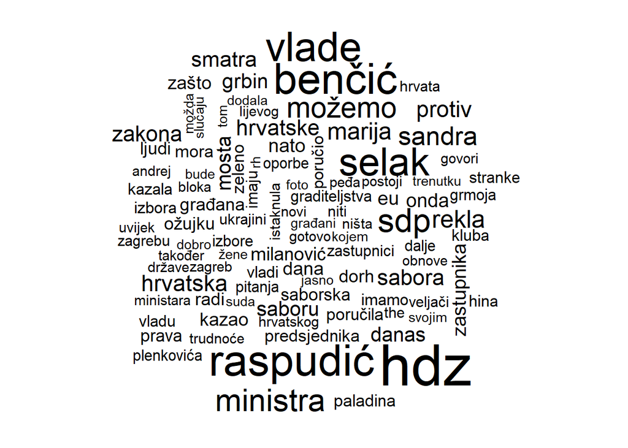

## Analiza sentimenta

### Frekvencija sentimenta kroz promatrano vrijeme po tjednima

##### **Što se događalo?**

###### Veljača -> uhićenje ministara (Horvat), istrage, afere (Ćorić), „pad“ vlade, traženje novog ministara, početak rata u Ukrajini.

###### Ožujak -> Opoziv ministara, pad drona kod Jaruna, pitanje korištenja novca iz EU fondova, zahtjev za rekonstrukcijom Vlade, Selak Raspudić trudna, pitanje spore obnove.

###### Travanj -> Afere, Možemo pobijedio DORH (tužba radi previše žena na listi), rekonstrukcija Vlade, kritika Milanovića i Plenkovića.

###### Svibanj -> Rasprave o raspuštanju Sabora, rasprava o Zakonu o pobačaju, slučaj Mirele Čavajde, prosvjed.

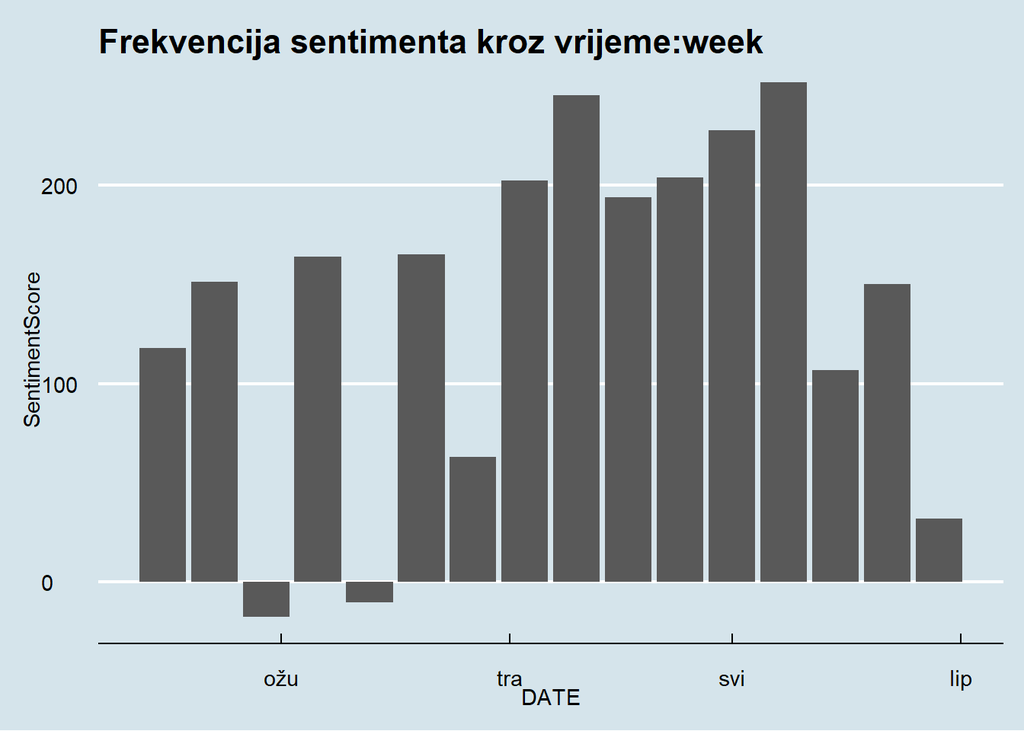

### Frekvencije riječi po sentimentu

##### Grafički prikaz top 15 najnegativnijih, neutralnih i najpozitivnijih riječi korištenih u objavama i njihova učestalost pojavljivanja. Vidimo da je najveća učestalost korištenja neutralnih riječi (*ministar, vlada, premijer…*), a među negativnim riječima ističu se: *problem, rat, prekid, afera….* Među pozitivnim riječima ističu se: *tim, imati, život, obnova…*

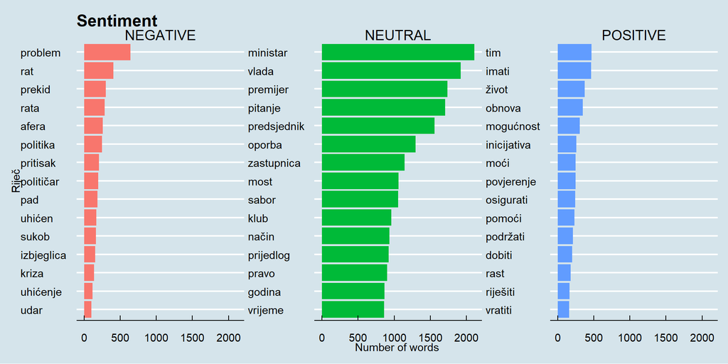

### Grafički prikaz frenkvencija korištenih riječi u “oblaku riječi” prema sentimentu

##### Prikaz prethodno navedenih top 15 negativnih, neutralnih i pozitivnih riječi u oblaku.

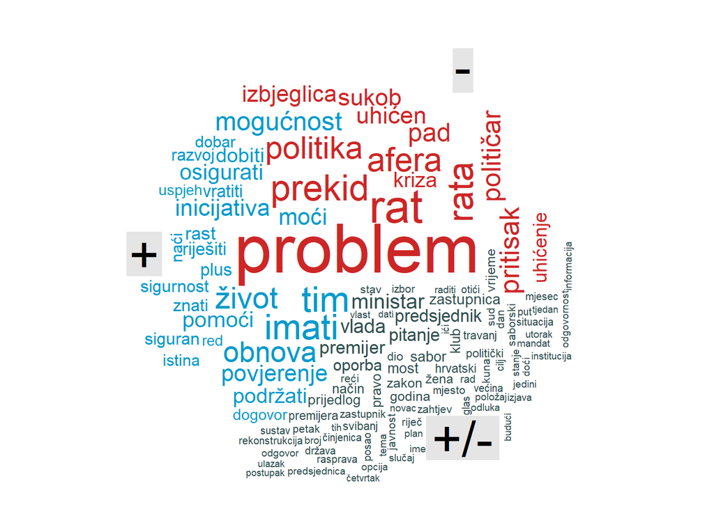

### Najnegativniji portali

```
## # A tibble: 207 x 4
##    FROM                   negWords  word negativnostIndex
##    <chr>                     <int> <int>            <dbl>
##  1 360hr.news                   27   723             3.73
##  2 zupanjac.net                 16   559             2.86
##  3 mojabih.live                 73  2949             2.48
##  4 novo.hr                      22   922             2.39
##  5 sabh.hr                      40  1765             2.27
##  6 sdss.hr                       8   354             2.26
##  7 vidiportal.ba                 9   399             2.26
##  8 most-hrvatska.hr             60  2663             2.25
##  9 ipress.hr                     9   419             2.15
## 10 varazdinske-vijesti.hr        7   329             2.13
## # ... with 197 more rows
```

##### Prikaz „najnegativnijih“ portala, odnosno onih koji su koristili najviše negativnih riječi. Vidljivi su portali, broj korištenih negativnih riječi, ukupan broj riječi te indeks negativnosti. Izdvojeno je prvih 10 najnegativnijih portala, gdje prvo mjestu po negativnosti zauzima 360hr.news s korištenih 27 negativnih riječi od njih sveukupno 723 i indexom negativnosti od 3.73. Iza slijede zupanjac.net, mojabih.live, novo.hr…

### Najpozitivniji portali

```
## # A tibble: 225 x 4
##    FROM                pozWords  word pozitivnostIndex
##    <chr>                  <int> <int>            <dbl>
##  1 dubrovnikinsider.hr        9   190             4.74
##  2 24vesti.com               10   244             4.10
##  3 medjugorje-info.com       61  1532             3.98
##  4 hkm.hr                    56  1469             3.81
##  5 liberoportal.hr           12   325             3.69
##  6 laudato.hr                 4   117             3.42
##  7 dalmacijanews.hr          18   569             3.16
##  8 skolskiportal.hr          12   386             3.11
##  9 nasabujstina.com           6   194             3.09
## 10 cgo-cce.org               11   361             3.05
## # ... with 215 more rows
```

##### Prikaz „najpozitivnijih“ portala, odnosno onih koji su koristili najviše pozitivnih riječi na navedenu temu. Navedena su imena portala, broj korištenih pozitivnih riječi, ukupan broj riječi i indeks pozitivnosti. Izdvojeno je top 10 najpozitivnijih portala, a na prvom mjestu je dubrovnikinsider.hr s indeksom pozitivnosti 4.74 i 9 pozitivnih riječi, a prate ga 24vesti.com i medjugorje-info.com.

### Najbitnije riječi u portalima s najvećim “dosegom”

```
##            FROM     word   n totWords     tf idf tf_idf
##  1:    index.hr    posto 312    21729 0.0144   0      0
##  2: direktno.hr    posto 240    29839 0.0080   0      0
##  3: direktno.hr      hdz 204    29839 0.0068   0      0
##  4: jutarnji.hr      hdz 198    22232 0.0089   0      0
##  5: jutarnji.hr    posto 178    22232 0.0080   0      0
##  6: direktno.hr raspudić 166    29839 0.0056   0      0
##  7:    index.hr      hdz 157    21729 0.0072   0      0
##  8:    index.hr raspudić 157    21729 0.0072   0      0
##  9: direktno.hr   benčić 155    29839 0.0052   0      0
## 10:    index.hr    selak 144    21729 0.0066   0      0
```

## Usporedba podataka

### Usporedba korištenja riječi “Benčić” i “Možemo”

##### Usporedba grafičkih prikaza kod korištenja riječi **„Benčić“** i **„Možemo“** na trima najaktivnijim portalima – *Direktno.hr, GlasIstre.hr i HRT.hr* kroz navedeni vremenski okvir. Na grafovima se može uočiti paralelna krivulja rasta i pada kod korištenja riječi „Benčić“ i posebno kod korištenja riječi „Možemo“, pa se iz njihove usporedbe može zaključiti da Sandra Benčić na navedenim portalima bilježi prisutnost u vrlo sličnoj mjeri kao i „Možemo“. Navedeno nas može uputiti na to da je Benčić usko povezana sa samom strankom, te da njena popularnost nije neovisna.

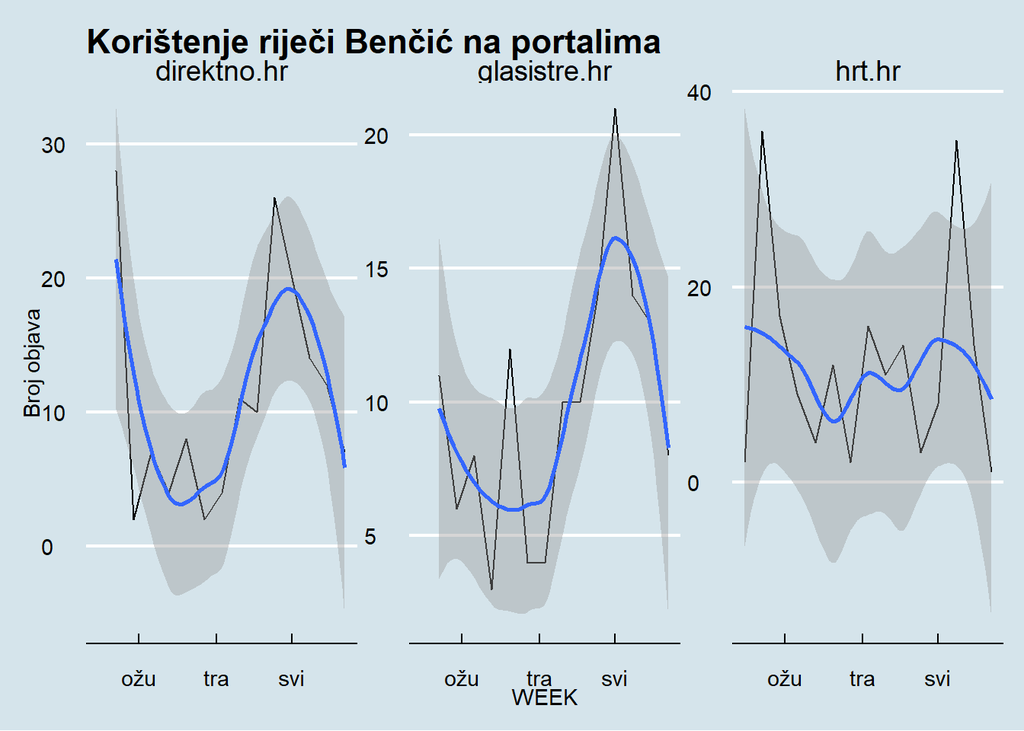

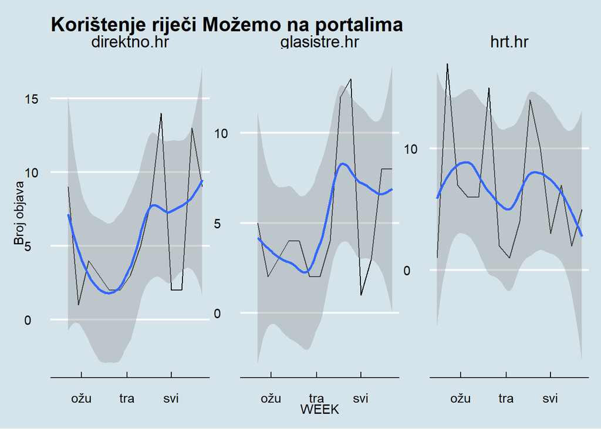

### Usporedba riječi “Selak” i “Most”

##### Usporedba grafičkih prikaza kod korištenja riječi **„Selak“** i **„Most“** na istim trima najaktivnijim portalima kroz navedeni vremenski okvir. Za razliku od prethodne usporedbe (Benčić – Možemo), ovdje vidimo da korištenje riječi „Selak“ na portalima nije nužno vezano uz korištenje riječi „Most“ (primjerice u travnju u glasistre.hr „Selak“ pada, dok „Most“ bilježi pad, ali i rast u istom mjesecu; isto tako na hrt.hr „Selak“ bilježi značajan rast u svibnju, dok „Most“ bilježi pad). Iz navedenog se može zaključiti da korištenje i popularnost riječi „Selak“ nije ovisno o korištenju riječi „Most“, odnosno stranka nije presudna za popularnost političarke.

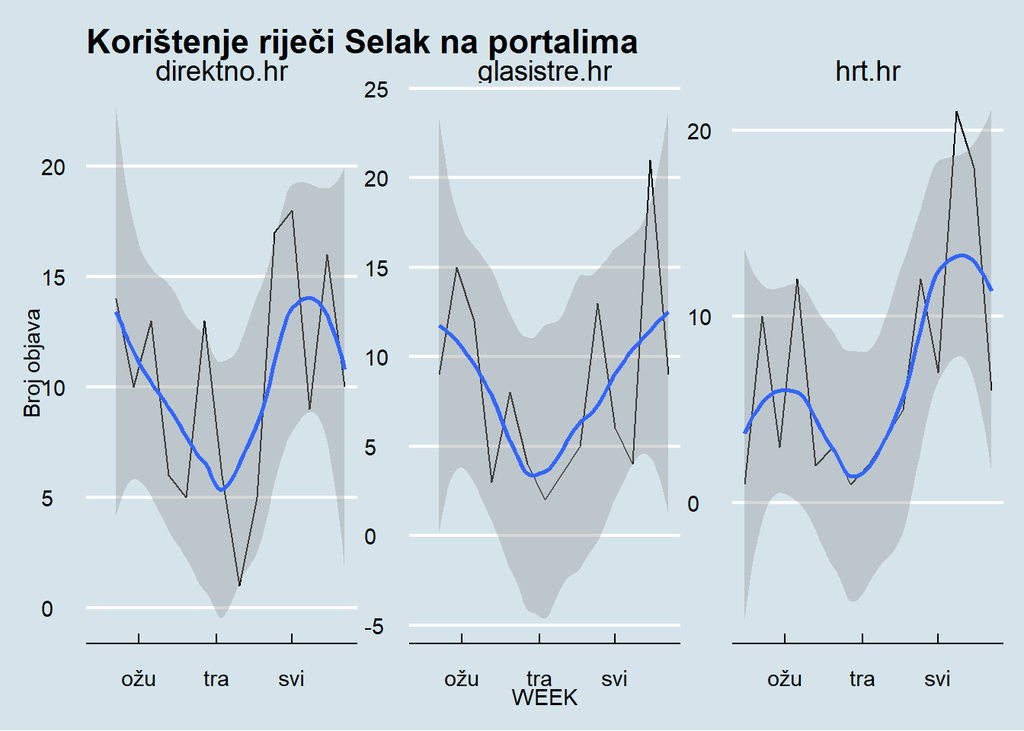

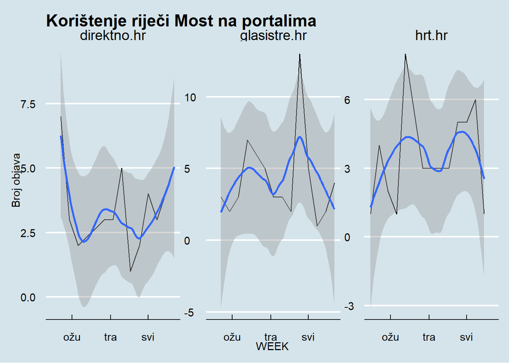